# Understanding convolutional autoencoders

## *Implementing Convolutional Autoencoder Architecture:*

[figure not shown]

```python
# torch snippets does a lot of default importing for you
# Whether it is numpy, pandas, matplotlib or the useful functions that are mentioned below Simply call
# ! pip install torch-snippets
```

```python
from torch_snippets import *
from torchvision.datasets import MNIST
from torchvision import transforms
```

```python
train_on_gpu = torch.cuda.is_available()
```

```python
img_transforms = transforms.Compose(
                    [transforms.ToTensor(),
                    transforms.Normalize([0.5], [0.5]),
                    transforms.Lambda(lambda x: x.cuda())])
```

```python
# ! pip install ipywidgets
```

```python
train_ds  = MNIST('/content', transform = img_transforms, train = True, download = True)
valid_ds = MNIST('/content', transform = img_transforms, train = False, download = True)
```

```
Downloading http://yann.lecun.com/exdb/mnist/train-images-idx3-ubyte.gz
Downloading http://yann.lecun.com/exdb/mnist/train-images-idx3-ubyte.gz to /content/MNIST/raw/train-images-idx3-ubyte.gz
```

```
Extracting /content/MNIST/raw/train-images-idx3-ubyte.gz to /content/MNIST/raw

Downloading http://yann.lecun.com/exdb/mnist/train-labels-idx1-ubyte.gz
Downloading http://yann.lecun.com/exdb/mnist/train-labels-idx1-ubyte.gz to /content/MNIST/raw/train-labels-idx1-ubyte.gz
```

```
Extracting /content/MNIST/raw/train-labels-idx1-ubyte.gz to /content/MNIST/raw

Downloading http://yann.lecun.com/exdb/mnist/t10k-images-idx3-ubyte.gz
Downloading http://yann.lecun.com/exdb/mnist/t10k-images-idx3-ubyte.gz to /content/MNIST/raw/t10k-images-idx3-ubyte.gz
```

```
Extracting /content/MNIST/raw/t10k-images-idx3-ubyte.gz to /content/MNIST/raw

Downloading http://yann.lecun.com/exdb/mnist/t10k-labels-idx1-ubyte.gz
Downloading http://yann.lecun.com/exdb/mnist/t10k-labels-idx1-ubyte.gz to /content/MNIST/raw/t10k-labels-idx1-ubyte.gz
```

```
Extracting /content/MNIST/raw/t10k-labels-idx1-ubyte.gz to /content/MNIST/raw
```

```python
batch_size = 128
train_loader = DataLoader(train_ds, batch_size = batch_size, shuffle = True)   # Note: torch_snippets has import DataLoader and many more function
valid_loader = DataLoader(valid_ds, batch_size = batch_size, shuffle = False)  # check official documents
```

> **`in_channels`**: is represent number of inputs(in depth). for instance: 3 for RGB and 1 for grayscale.

> **`out_channels:-`** number of output channels, i.e. number of filtered "images" a convolutional layer is made of or the number of unique, convolutional kernels that will be applied to an input.

```python
class ConvAutoEncoder(nn.Module):
    def __init__(self):
        super().__init__()
        # Define encoder
        self.encoder = nn.Sequential(
                            nn.Conv2d(in_channels = 1, out_channels = 32, kernel_size = 3, stride = 3 , padding = 1),
                            nn.ReLU(True),
                            nn.MaxPool2d(2, stride = 2),
                            nn.Conv2d(in_channels = 32, out_channels = 64, kernel_size = 3, stride = 2, padding = 1),
                            nn.ReLU(True),
                            nn.MaxPool2d(2, stride = 1))
        # Define decoder
        self.decoder = nn.Sequential(
                            nn.ConvTranspose2d(in_channels = 64, out_channels = 32, kernel_size = 3, stride = 2),
                            nn.ReLU(True),
                            nn.ConvTranspose2d(in_channels = 32, out_channels = 16, kernel_size = 5, stride = 3, padding = 1),
                            nn.ReLU(True),
                            nn.ConvTranspose2d(in_channels = 16, out_channels = 1, kernel_size = 2, stride = 2, padding = 1),
                            nn.Tanh())

        # Define foward method
    def forward(self, x):
        x = self.encoder(x)
        x = self.decoder(x)
        return x
```

**Comprehension of the first convolutional layer:** *Say, I'm constructing a CNN, and my input layer accepts grayscale images that are 200 by 200 pixels (corresponding to a 3D array with height 200, widht 200, and depth 1). Then, say I'd like the next layer to be a convolutional layer with 32 filers, each filer haveing a widht and height of 3. When performing the convolution, I'd like the filter to jump 3 pixels at a time. I also want the filer to extend outside of the image boundaries; in other words, I want to pad the image with 1.*

```python
model = ConvAutoEncoder().cuda()
```

```python
! pip install torch_summary
from torchsummary import summary
summary(model, torch.zeros(2,1,28,28)); # Still this code isn't working problem from PyTorch
# Just printing the model
# print(model)
```

```
WARNING: Running pip as the 'root' user can result in broken permissions and conflicting behaviour with the system package manager. It is recommended to use a virtual environment instead: https://pip.pypa.io/warnings/venv
==========================================================================================
Layer (type:depth-idx)                   Output Shape              Param #
==========================================================================================
├─Sequential: 1-1                        [-1, 64, 2, 2]            --
|    └─Conv2d: 2-1                       [-1, 32, 10, 10]          320
|    └─ReLU: 2-2                         [-1, 32, 10, 10]          --
|    └─MaxPool2d: 2-3                    [-1, 32, 5, 5]            --
|    └─Conv2d: 2-4                       [-1, 64, 3, 3]            18,496
|    └─ReLU: 2-5                         [-1, 64, 3, 3]            --
|    └─MaxPool2d: 2-6                    [-1, 64, 2, 2]            --
├─Sequential: 1-2                        [-1, 1, 28, 28]           --
|    └─ConvTranspose2d: 2-7              [-1, 32, 5, 5]            18,464
|    └─ReLU: 2-8                         [-1, 32, 5, 5]            --
|    └─ConvTranspose2d: 2-9              [-1, 16, 15, 15]          12,816
|    └─ReLU: 2-10                        [-1, 16, 15, 15]          --
|    └─ConvTranspose2d: 2-11             [-1, 1, 28, 28]           65
|    └─Tanh: 2-12                        [-1, 1, 28, 28]           --
==========================================================================================
Total params: 50,161
Trainable params: 50,161
Non-trainable params: 0
Total mult-adds (M): 3.64
==========================================================================================
Input size (MB): 0.01
Forward/backward pass size (MB): 0.07
Params size (MB): 0.19
Estimated Total Size (MB): 0.27
==========================================================================================
```

```python
summary(model, torch.zeros(1,1,28,28)); # We just pass the sample input as torch.zeros(1,1,28,28)
```

```
==========================================================================================
Layer (type:depth-idx)                   Output Shape              Param #
==========================================================================================
├─Sequential: 1-1                        [-1, 64, 2, 2]            --
|    └─Conv2d: 2-1                       [-1, 32, 10, 10]          320
|    └─ReLU: 2-2                         [-1, 32, 10, 10]          --
|    └─MaxPool2d: 2-3                    [-1, 32, 5, 5]            --
|    └─Conv2d: 2-4                       [-1, 64, 3, 3]            18,496
|    └─ReLU: 2-5                         [-1, 64, 3, 3]            --
|    └─MaxPool2d: 2-6                    [-1, 64, 2, 2]            --
├─Sequential: 1-2                        [-1, 1, 28, 28]           --
|    └─ConvTranspose2d: 2-7              [-1, 32, 5, 5]            18,464
|    └─ReLU: 2-8                         [-1, 32, 5, 5]            --
|    └─ConvTranspose2d: 2-9              [-1, 16, 15, 15]          12,816
|    └─ReLU: 2-10                        [-1, 16, 15, 15]          --
|    └─ConvTranspose2d: 2-11             [-1, 1, 28, 28]           65
|    └─Tanh: 2-12                        [-1, 1, 28, 28]           --
==========================================================================================
Total params: 50,161
Trainable params: 50,161
Non-trainable params: 0
Total mult-adds (M): 3.64
==========================================================================================
Input size (MB): 0.00
Forward/backward pass size (MB): 0.07
Params size (MB): 0.19
Estimated Total Size (MB): 0.26
==========================================================================================
```

From the preceding summary, we can see that the `MaxPool2d-6` layer with a shape of batch size x 64 x 2 x 2 acts as the bottleneck layer

```python
# Define a function to train on a batch of data (train_batch)
def train_batch(input, model, criterion, optimizer):
    model.train()
    optimizer.zero_grad()
    output = model(input)
    loss = criterion(output, input)
    loss.backward()
    optimizer.step()
    return loss
```

```python
# Define the function to validate on the batch of data (validate_batch):
@torch.no_grad()
def valid_batch(input, model, criterion):
    model.eval()
    output = model(input)
    loss = criterion(output, input)
    return loss
```

```python
# Define the model, loss criterion, and optimizer:
model = ConvAutoEncoder().cuda()
criterion = nn.MSELoss()
optimizer = optim.AdamW(model.parameters(), lr = 0.001, weight_decay = 0.00001)
```

```python
# Train the model over increasing epochs:
num_epochs = 10
log = Report(num_epochs)

for epoch in range(num_epochs):
    # This is for training
    N = len(train_loader)
    for idx, (data, _) in enumerate(train_loader):
        train_loss = train_batch(data, model, criterion, optimizer)
        log.record(pos = (epoch + (idx+1)/N), train_loss = train_loss, end = '\r')

    # This is for validation
    N = len(valid_loader)
    for idx, (data, _) in enumerate(valid_loader):
        val_loss = valid_batch(data, model, criterion)
        log.record(pos = (epoch + (idx+1)/N), valid_loss = val_loss, end = '\r')

    log.report_avgs(epoch+1)
```

```
EPOCH: 1.000	train_loss: 0.172	valid_loss: 0.097	(16.92s - 152.24s remaining)
EPOCH: 2.000	train_loss: 0.086	valid_loss: 0.074	(33.83s - 135.34s remaining)
EPOCH: 3.000	train_loss: 0.071	valid_loss: 0.065	(50.69s - 118.28s remaining)
EPOCH: 4.000	train_loss: 0.064	valid_loss: 0.059	(67.29s - 100.93s remaining)
EPOCH: 5.000	train_loss: 0.059	valid_loss: 0.055	(84.40s - 84.40s remaining)
EPOCH: 6.000	train_loss: 0.056	valid_loss: 0.053	(101.31s - 67.54s remaining)
EPOCH: 7.000	train_loss: 0.053	valid_loss: 0.051	(118.18s - 50.65s remaining)
EPOCH: 8.000	train_loss: 0.051	valid_loss: 0.049	(135.40s - 33.85s remaining)
EPOCH: 9.000	train_loss: 0.050	valid_loss: 0.048	(152.34s - 16.93s remaining)
EPOCH: 10.000	train_loss: 0.048	valid_loss: 0.047	(168.81s - 0.00s remaining)
```

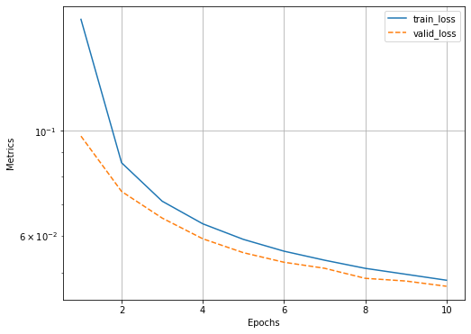

```python
log.plot_epochs(log=True)
```

```python
valid_ds[0]
```

[output not shown]

[output cut: 59 more lines]

[output not shown]

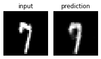

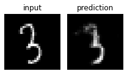

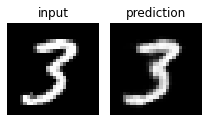

```python
# Validate the model on the val_ds dataset, which was not provided during training:

for _ in range(3):
    idx = np.random.randint(len(valid_ds))
    im, _ = valid_ds[idx]
    _im = model(im[None])[0]
    fig, ax = plt.subplots(1, 2, figsize=(3,3))
    show(im[0], ax = ax[0], title = 'input')
    show(_im[0], ax = ax[1], title = 'prediction')
    plt.tight_layout()
    plt.show()
```

> **In the next section,** we will address the question of grouping similar images based on bottleneck layer values when the labels of images are not present.

# Grouping similar images using t-SNE

> **"t-SNE"** that visualizes high-dimensional data by giving each datapoint a location in a two or three-dimensional map.

This way, our understanding that similar images will have similar [embeddings](https://stackoverflow.com/questions/25692293/inserting-a-link-to-a-webpage-in-an-ipython-notebook) can be proved, as similar images should be clustered together in the two-dimensional plane. In the following code, we will represent [embeddings](https://stackoverflow.com/questions/25692293/inserting-a-link-to-a-webpage-in-an-ipython-notebook) of all the test images in a two dimensional plane

Step1: Initialize lists so that we store the latent vectors (latent_vectors) and the corresponding classes of images (note that we store the class of each image only to verify if images of the same class, which are expected to have a very high similarity with each other, are indeed close to each other in terms of representation):

```python
for im, clss in valid_loader:
    print(im, clss, end=" ")
    print('This is shape of image :', im.shape,'This is the shape:', clss.shape)
    break
```

[output not shown]

```python
print(im.shape)
print(im.view(len(im), -1).shape)
```

```
torch.Size([128, 1, 28, 28])
torch.Size([128, 784])
```

```python
latent_vectors = []
classes = []
```

`Encoder:` encoder layer has similiar embedding with similiar images

```python
model.encoder(im)
```

[output not shown]

[output cut: 73 more lines]

[output not shown]

Loop through the images in the validation dataloader (valid_loader) and store the output of the encoder layer

```python
model.encoder(im).view(len(im), -1)
```

```
tensor([[8.0563e+00, 5.7273e+00, 4.4406e+00,  ..., 1.9643e+00, 1.9643e+00,
         1.9643e+00],
        [9.2849e+00, 3.2101e+00, 7.4884e+00,  ..., 2.6725e+00, 2.6725e+00,
         2.6725e+00],
        [6.2988e+00, 5.6800e+00, 4.8329e+00,  ..., 0.0000e+00, 0.0000e+00,
         0.0000e+00],
        ...,
        [7.0143e+00, 5.1559e+00, 4.4270e+00,  ..., 7.6447e-03, 2.3349e-01,
         2.3349e-01],
        [8.7365e+00, 4.9789e+00, 4.2323e+00,  ..., 4.5896e+00, 4.5896e+00,
         4.5896e+00],
        [8.2586e+00, 7.5289e+00, 5.7220e+00,  ..., 4.3002e+00, 4.3002e+00,
         4.3002e+00]], device='cuda:0', grad_fn=<ViewBackward0>)
```

```python
for im, clss in valid_loader:
    latent_vectors.append(model.encoder(im).view(len(im), -1))
    classes.extend(clss)
```

```python
latent_vectors = torch.cat(latent_vectors).cpu().detach().numpy()
```

Import t-SNE (TSNE) and specify that each vector is to be converted into a 2-dimensional vector (TSNE(2)) so that we can plot it:

```python
from sklearn.manifold import TSNE
tsne = TSNE(2)
```

Fit t-SNE by running the fit_transform method on image embeddings (latent_vectors):

```python
clustered = tsne.fit_transform(latent_vectors)
```

```python
len(classes)
```

```
10000
```

Zip [discussion](https://stackoverflow.com/questions/25858834/can-somebody-give-me-an-example-for-the-zip-function-in-python) will give you some gist to understand following code

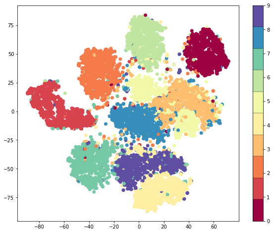

```python
fig = plt.figure(figsize = (10, 8))
cmap = plt.get_cmap('Spectral', 10)
plt.scatter(*zip(*clustered), c = classes, cmap = cmap)
plt.colorbar(drawedges=True)
```

**Conclusion:** We can see that images of the same class are clustered together, which reinforces our understanding that the bottleneck layer has values in such a way that images that look similar will have similar values.